# Project : Investigate a Dataset : (No Show Appointments - kagglev2 , may/2016)

- Introduction
- Data Wrangling
- Exploratory Data Analysis
- Conclusions

## Introduction

### Question(s) for Analysis

> 1) Can Gender affect visit?  
> 2) Can Age affect visit?  
> 3) what about the Neighborhood?  
> 4) what about the Scholarship?  
> 5) what about the Hypertension?  
> 6) what about the Diabetes?  
> 7) what about the Alcoholism?  
> 8) what about the Handicap?  
> 9) what about the SMS_received?  
> --**Can this features affect medical appointment**--

```python
#import important Libraries
import pandas as pd
import numpy as np
import matplotlib.pyplot as plt
import seaborn as sns
%matplotlib inline
```

## Data Dictionary

> PatientID — a unique identifier of a patient  
> AppointmentID — a unique identifier of an appointment  
> Gender — patient (Male or Female )  
> ScheduledDay — a day when an appointment is planned to occur.  
> AppointmentDay — a real date of an appointment  
> Age — a patient’s age.  
> Neighborhood — a neighborhood of each patient  
> Scholarship — Does the patient receive a scholarship?  
> Hypertension — Does the patient have hypertension?  
> Diabetes — The patient has diabetes or not  
> Alcoholism — Is the patient addicted to alcohol or not?  
> Handicap — The patient has a handicap or not and with a handicap order  
> SMS_received — Has the patient received an SMS reminder?  
> No_show — Has the patient decided not to show up?

## Data Wrangling

### General Properties

```python
df=pd.read_csv('Database_No_show_appointments//noshowappointments-kagglev2-may-2016.csv')
df.head()
```

|  | PatientId | AppointmentID | Gender | ScheduledDay | AppointmentDay | Age | Neighbourhood | Scholarship | Hipertension | Diabetes | Alcoholism | Handcap | SMS_received | No-show |
| --- | --- | --- | --- | --- | --- | --- | --- | --- | --- | --- | --- | --- | --- | --- |
| 0 | 2.987250e+13 | 5642903 | F | 2016-04-29T18:38:08Z | 2016-04-29T00:00:00Z | 62 | JARDIM DA PENHA | 0 | 1 | 0 | 0 | 0 | 0 | No |
| 1 | 5.589978e+14 | 5642503 | M | 2016-04-29T16:08:27Z | 2016-04-29T00:00:00Z | 56 | JARDIM DA PENHA | 0 | 0 | 0 | 0 | 0 | 0 | No |
| 2 | 4.262962e+12 | 5642549 | F | 2016-04-29T16:19:04Z | 2016-04-29T00:00:00Z | 62 | MATA DA PRAIA | 0 | 0 | 0 | 0 | 0 | 0 | No |
| 3 | 8.679512e+11 | 5642828 | F | 2016-04-29T17:29:31Z | 2016-04-29T00:00:00Z | 8 | PONTAL DE CAMBURI | 0 | 0 | 0 | 0 | 0 | 0 | No |
| 4 | 8.841186e+12 | 5642494 | F | 2016-04-29T16:07:23Z | 2016-04-29T00:00:00Z | 56 | JARDIM DA PENHA | 0 | 1 | 1 | 0 | 0 | 0 | No |

```python
#Exploration Data Shape
df.shape
```

```
(110527, 14)
```

```python
#The basic information about the data
df.info()
```

```
<class 'pandas.core.frame.DataFrame'>
RangeIndex: 110527 entries, 0 to 110526
Data columns (total 14 columns):
 #   Column          Non-Null Count   Dtype
---  ------          --------------   -----
 0   PatientId       110527 non-null  float64
 1   AppointmentID   110527 non-null  int64
 2   Gender          110527 non-null  object
 3   ScheduledDay    110527 non-null  object
 4   AppointmentDay  110527 non-null  object
 5   Age             110527 non-null  int64
 6   Neighbourhood   110527 non-null  object
 7   Scholarship     110527 non-null  int64
 8   Hipertension    110527 non-null  int64
 9   Diabetes        110527 non-null  int64
 10  Alcoholism      110527 non-null  int64
 11  Handcap         110527 non-null  int64
 12  SMS_received    110527 non-null  int64
 13  No-show         110527 non-null  object
dtypes: float64(1), int64(8), object(5)
memory usage: 11.8+ MB
```

### Are there duplicate values in the data ?

```python
df.duplicated().any()
```

```
False
```

### Note : that there are no null values in the data

```python
#find out the null values in the data
df.isnull().sum()
```

```
PatientId         0
AppointmentID     0
Gender            0
ScheduledDay      0
AppointmentDay    0
Age               0
Neighbourhood     0
Scholarship       0
Hipertension      0
Diabetes          0
Alcoholism        0
Handcap           0
SMS_received      0
No-show           0
dtype: int64
```

- You will notice in the data that there are incorrectly in the type of columns like AppointmentDay and scheduledDay,we need to convert the type of these columns as datatime.

```python
#Converting columns (AppointmentDay and scheduledDay) from String to datetime .
df.AppointmentDay=pd.to_datetime(df.AppointmentDay)
df.ScheduledDay=pd.to_datetime(df.ScheduledDay)
```

```python
df.info()
```

```
<class 'pandas.core.frame.DataFrame'>
RangeIndex: 110527 entries, 0 to 110526
Data columns (total 14 columns):
 #   Column          Non-Null Count   Dtype
---  ------          --------------   -----
 0   PatientId       110527 non-null  float64
 1   AppointmentID   110527 non-null  int64
 2   Gender          110527 non-null  object
 3   ScheduledDay    110527 non-null  datetime64[ns, UTC]
 4   AppointmentDay  110527 non-null  datetime64[ns, UTC]
 5   Age             110527 non-null  int64
 6   Neighbourhood   110527 non-null  object
 7   Scholarship     110527 non-null  int64
 8   Hipertension    110527 non-null  int64
 9   Diabetes        110527 non-null  int64
 10  Alcoholism      110527 non-null  int64
 11  Handcap         110527 non-null  int64
 12  SMS_received    110527 non-null  int64
 13  No-show         110527 non-null  object
dtypes: datetime64[ns, UTC](2), float64(1), int64(8), object(3)
memory usage: 11.8+ MB
```

### Well,the data type for all columns is correct

- I see that columns (AppointmentDay and scheduledDay) do not consider them of great importance in the data and do not influence me whether the patient comes to the appointment or not,So I decided to drop them.

```python
df.drop(['ScheduledDay','AppointmentDay'],axis=1,inplace=True)
```

- There are two columns are indicating serial numbers(PatientId,AppointmentID).
  - These numbers do not affect the results.
    - So I decided to drop them.

```python
df.drop(['PatientId','AppointmentID'],axis=1,inplace=True)
```

```python
df.head()
```

|  | Gender | Age | Neighbourhood | Scholarship | Hipertension | Diabetes | Alcoholism | Handcap | SMS_received | No-show |
| --- | --- | --- | --- | --- | --- | --- | --- | --- | --- | --- |
| 0 | F | 62 | JARDIM DA PENHA | 0 | 1 | 0 | 0 | 0 | 0 | No |
| 1 | M | 56 | JARDIM DA PENHA | 0 | 0 | 0 | 0 | 0 | 0 | No |
| 2 | F | 62 | MATA DA PRAIA | 0 | 0 | 0 | 0 | 0 | 0 | No |
| 3 | F | 8 | PONTAL DE CAMBURI | 0 | 0 | 0 | 0 | 0 | 0 | No |
| 4 | F | 56 | JARDIM DA PENHA | 0 | 1 | 1 | 0 | 0 | 0 | No |

### Data Cleaning

#### Fixing typos in data columns.

```python
df.rename(columns = {'Hipertension': 'Hypertension',
                'Handcap': 'Handicap','No-show':'No_show'}, inplace = True)
```

#### we fix any age has values less 0 because it's not make sense to have those values

```python
np.sort(df.Age.unique())
```

```
array([ -1,   0,   1,   2,   3,   4,   5,   6,   7,   8,   9,  10,  11,
        12,  13,  14,  15,  16,  17,  18,  19,  20,  21,  22,  23,  24,
        25,  26,  27,  28,  29,  30,  31,  32,  33,  34,  35,  36,  37,
        38,  39,  40,  41,  42,  43,  44,  45,  46,  47,  48,  49,  50,
        51,  52,  53,  54,  55,  56,  57,  58,  59,  60,  61,  62,  63,
        64,  65,  66,  67,  68,  69,  70,  71,  72,  73,  74,  75,  76,
        77,  78,  79,  80,  81,  82,  83,  84,  85,  86,  87,  88,  89,
        90,  91,  92,  93,  94,  95,  96,  97,  98,  99, 100, 102, 115],
      dtype=int64)
```

```python
df[df.Age==-1].shape[0]
```

```
1
```

```python
df=df[df.Age>=0]
```

```python
np.sort(df.Age.unique())
```

```
array([  0,   1,   2,   3,   4,   5,   6,   7,   8,   9,  10,  11,  12,
        13,  14,  15,  16,  17,  18,  19,  20,  21,  22,  23,  24,  25,
        26,  27,  28,  29,  30,  31,  32,  33,  34,  35,  36,  37,  38,
        39,  40,  41,  42,  43,  44,  45,  46,  47,  48,  49,  50,  51,
        52,  53,  54,  55,  56,  57,  58,  59,  60,  61,  62,  63,  64,
        65,  66,  67,  68,  69,  70,  71,  72,  73,  74,  75,  76,  77,
        78,  79,  80,  81,  82,  83,  84,  85,  86,  87,  88,  89,  90,
        91,  92,  93,  94,  95,  96,  97,  98,  99, 100, 102, 115],
      dtype=int64)
```

## Exploratory Data Analysis

```python
# We can make functions for repeated code
def plot(label1):
    ax=sns.countplot(x=df[label1],hue=df.No_show,data=df)
    ax.set_title("Show/NoShow Patients for {}".format(label1))
    x_ticks_labels=['No {}','{}'.format(label1,label1)]
    plt.show()
```

```python
plt.style.use('bmh')
```

#### Before anything , let's see how many patients attended

```python
df['No_show'].value_counts()
```

```
No     88207
Yes    22319
Name: No_show, dtype: int64
```

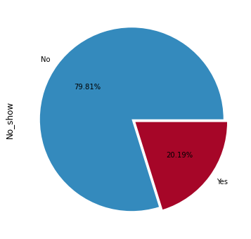

```python
df.No_show.value_counts().plot.pie(figsize=(6,6), autopct='%.2f%%', explode=(0, .05))
plt.show()
```

##### We can see that out of 110526 patients around 88207 of them have turned up and that is around 80%

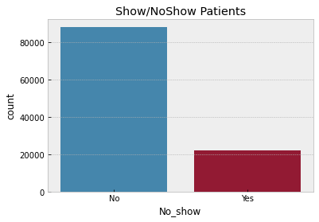

```python
ax=sns.countplot(x=df.No_show,data=df)
ax.set_title("Show/NoShow Patients")
plt.show()
```

### Research Question 1 (Can Gender affect visit?)

```python
print("Unique Values in Gender ",df.Gender.unique())
```

```
Unique Values in Gender  ['F' 'M']
```

```python
df['Gender'].value_counts()
```

```
F    71839
M    38687
Name: Gender, dtype: int64
```

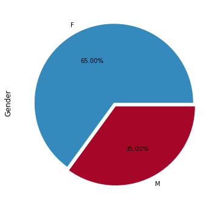

```python
df.Gender.value_counts().plot.pie(figsize=(6,6), autopct='%.2f%%', explode=(0, .05))
plt.show()
```

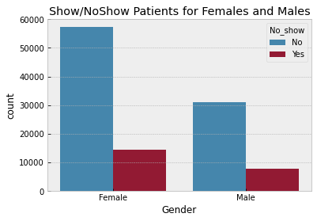

```python
ax=sns.countplot(x=df.Gender,hue=df.No_show,data=df)
ax.set_title("Show/NoShow Patients for Females and Males")
x_ticks_labels=['Female','Male']
ax.set_xticklabels(x_ticks_labels)
plt.show()
```

- We can see that of the 88,000 patients that appeared , about 57,000 were famale and 31,000 were male.Of the 22,500 patients who did not come for a visit ,about 15,000 were female and 7,500 were males .
  - For Female 26% (Percentage of Females who did not attend to those who attended)
  - For male 24% (Percentage of Males who did not attend to those who attended)
  - SO,Gender does not affect .

### Research Question 2 ( Can Age affect visit?)

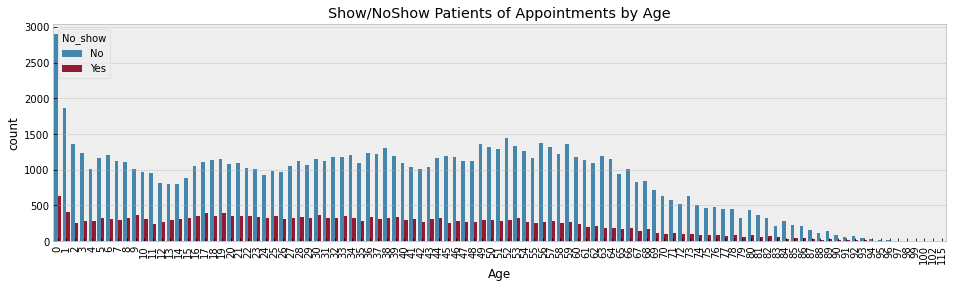

```python
plt.figure(figsize=(16,4))
plt.xticks(rotation=90)
ax=sns.countplot(x=df.Age,hue=df.No_show)
ax.set_title("Show/NoShow Patients of Appointments by Age")
plt.show()
```

- From the above visualization,it appears that the ratio of Show to NoShow is nearly the same for all ages except for "Age 0" and "Age 1" .
  - So,age does not affect the commitment to visit much

### Research Question 3 (what about the Neighborhood?)

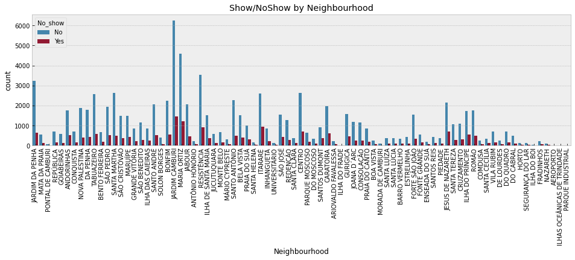

```python
#Below we will see the patients count for each Neighborhood.
plt.figure(figsize=(16,4))
plt.xticks(rotation=90)
ax=sns.countplot(x=df.Neighbourhood,hue=df.No_show)
ax.set_title("Show/NoShow by Neighbourhood")
plt.show()
```

### Research Question 4 (what about the Scholarship?)

```python
df['Scholarship'].value_counts()
```

```
0    99665
1    10861
Name: Scholarship, dtype: int64
```

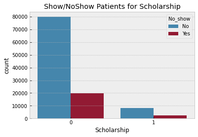

```python
plot('Scholarship')
```

- From visualization we can see that there are around 100,000 patients without Scholarship and out of them around 80% have come for the visit .
- Out of the 10,800 patients with Scholarship around 75% of them have come for the visit .
- So, Scholarship feature could help us in determining if a patient append the appointment or not .

### Research Question 5 (what about the Hypertension?)

```python
df['Hypertension'].value_counts()
```

```
0    88725
1    21801
Name: Hypertension, dtype: int64
```

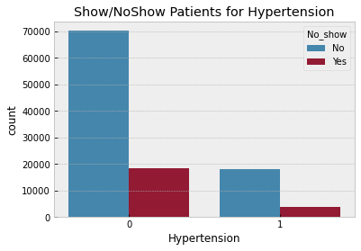

```python
plot('Hypertension')
```

### Research Question 6 (what about the Diabetes?)

```python
df['Diabetes'].value_counts()
```

```
0    102583
1      7943
Name: Diabetes, dtype: int64
```

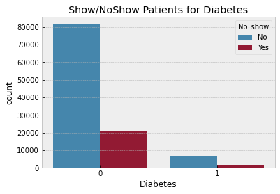

```python
plot('Diabetes')
```

### Research Question 7 (what about the Alcoholism?)

```python
df['Alcoholism'].value_counts()
```

```
0    107166
1      3360
Name: Alcoholism, dtype: int64
```

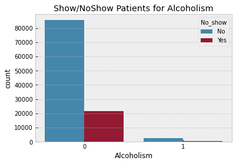

```python
plot('Alcoholism')
```

- By visualizing, we can see that there are about 107,000 patients who do not suffer from alcoholism and about 80% of them attended the visit.
- Of the 3360 patients with alcohol addiction, about 80% attended the visit.
- Since the rate of visits for non-alcoholic patients is the same, this may not help us determine whether or not the patient is coming for a visit

### Research Question 8 (what about the Handicap?)

```python
df['Handicap'].value_counts()
```

```
0    108285
1      2042
2       183
3        13
4         3
Name: Handicap, dtype: int64
```

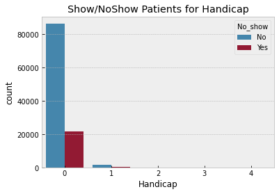

```python
ax=sns.countplot(x=df.Handicap,hue=df.No_show,data=df)
ax.set_title("Show/NoShow Patients for Handicap")
plt.show()
```

### Research Question 9 (what about the SMS_received?)

```python
df['SMS_received'].value_counts()
```

```
0    75044
1    35482
Name: SMS_received, dtype: int64
```

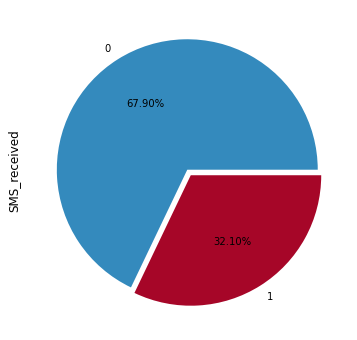

```python
df.SMS_received.value_counts().plot.pie(figsize=(6,6), autopct='%.2f%%', explode=(0, .05))
plt.show()
```

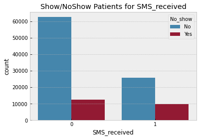

```python
plot('SMS_received')
```

- By visualization, we can see that there are about 75,000 patients who did not receive text messages, and about 84% of them attended the visit.
- Of the 35,500 patients who received text messages, about 72% attended the visit.
- This feature will help us determine if a patient will come for a visit after scheduling an appointment.

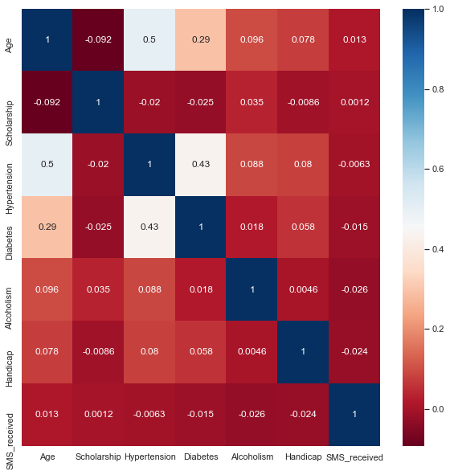

```python
#Heatmap Correlation among Features .
sns.set(rc = {'figure.figsize':(10,10)})
sns.heatmap(df.corr(),cmap='RdBu',annot=True)
```

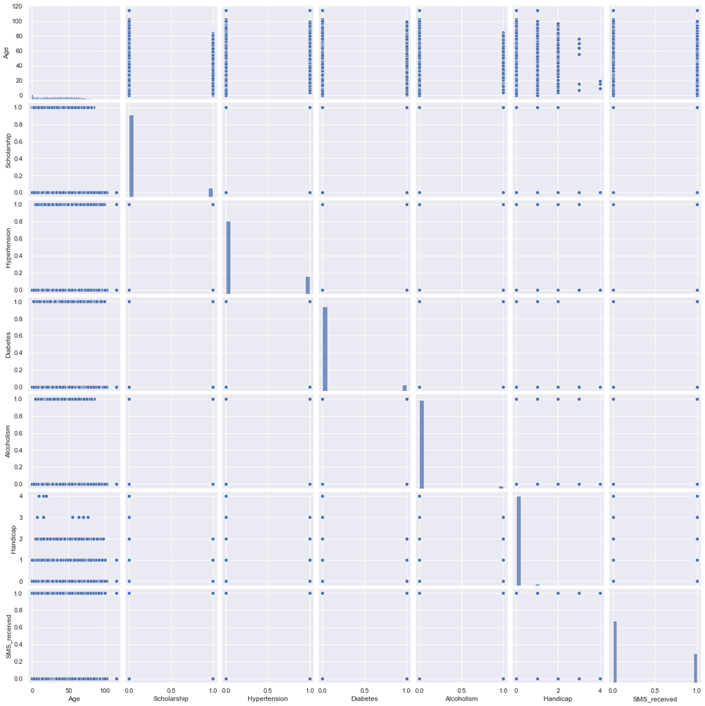

```python
sns.pairplot(df)
```

## * "SMS_received ,Scholarship,Diabetes,Hypertension" This features will help us determine if a patient will come for a visit after scheduling an appointment.

## * The features such as different "Gender ,Age , Alcoholism" are not a factor to decide if the person would come to his appointment or not!

## * One limitation of this analysis was the lack of background information. In the initial analysis of the data it was found that only 32% of the appointments had SMS messages received. It is possible that patients were more likely to be encouraged to enroll in SMS notifications after they have already missed an appointment. That would mean that those who were receiving SMSes were also more likely to have problems making appointments.

## * As we can see about 20.2% of people that schedule an appointment did not make it to thier appointment

### Limitations :

- Missing features that could be useful to get more sure what is the most feature that impacts showing to the appointment such as if the patient is employeed or not , or whether the patient have a series medical issue or not.
- There we some illogical data such as patients with age 0 or less.

## Submitting your Project

> Before you submit your project, you need to create a .html or .pdf version of this notebook in the workspace here. To do that, run the code cell below. If it worked correctly, you should get a return code of 0, and you should see the generated .html file in the workspace directory (click on the orange Jupyter icon in the upper left).

> Alternatively, you can download this report as .html via the **File** > **Download as** submenu, and then manually upload it into the workspace directory by clicking on the orange Jupyter icon in the upper left, then using the Upload button.

> Once you've done this, you can submit your project by clicking on the "Submit Project" button in the lower right here. This will create and submit a zip file with this .ipynb doc and the .html or .pdf version you created. Congratulations!

```python
from subprocess import call
call(['python', '-m', 'nbconvert', 'Investigate_a_Dataset.ipynb'])
```

```
1
```